# Lecture 3: Marketing Mix Modeling

How to Measure What Your Marketing Actually Does

## Motivating Problem

**Tip**

**Setting:** A firm allocates advertising budget across TV, digital, and social. Which channel is **actually** driving revenue — and how should you reallocate?

**Learning Objectives**

- Apply the adstock transformation to model advertising carryover
- Evaluate a channel’s efficiency using the Hill function, on the adstock scale
- Interpret MMM outputs: decay parameters, EC50, marginal ROI
- Recommend budget reallocations from model output
- Explain why last-touch attribution misleads budget decisions

## Why Last-Touch Attribution Fails

Customer journey: **TV ad → Instagram → Google Search → Purchase**

Last-touch credits: 100% to Google Search

TV ad created the desire. Instagram reinforced it. Search just captured it.

**Warning**

Last-touch systematically **kills awareness budgets** and **overcredits** closing channels like branded paid search.

MMM solves this by modeling the **statistical relationship** between spend and revenue, accounting for delayed effects.

## Adstock: Advertising Carryover

An ad seen today still influences purchasing next week and the week after.

$$A_t = S_t + \lambda \cdot A_{t-1}, \qquad A_0 = 0, \quad 0 \leq \lambda < 1$$

$\lambda$ = **decay rate** (fraction of last week’s advertising that persists)

**Warning**

**$A_t$ is spend, not revenue.** Adstock is measured in dollars of *spend* — the next slide’s “$A_3 = 122$” means week 3 behaves like a week you had spent $122k in. The **revenue** effect is $\beta \cdot H(A_t)$, three slides on. Both get called “the advertising effect”; they are not the same number.

**$\lambda = 0.9$** (TV)  
Slow decay — brand effects persist  
Long memory

**$\lambda = 0.2$** (Search)  
Fast decay — effect is immediate  
Short memory

## Adstock: Worked Example

$\lambda = 0.6$, spend = [200, 0, 50, 0]

| Week | Spend $S_t$ | Adstock $A_t$ |
| --- | --- | --- |
| 1 | 200 | $200 + 0.6 \times 0 = \mathbf{200.0}$ |
| 2 | 0 | $0 + 0.6 \times 200 = \mathbf{120.0}$ |
| 3 | 50 | $50 + 0.6 \times 120 = \mathbf{122.0}$ |
| 4 | 0 | $0 + 0.6 \times 122 = \mathbf{73.2}$ |

**Total adstock generated by a single $200 impulse** — a sum *over time*:

$$\sum_{t=0}^{\infty} \lambda^t \cdot S = \frac{S}{1-\lambda} = \frac{200}{1-0.6} = \mathbf{500}$$

**Note**

The same expression returns two slides on as a **level**: spend $200 *every* week and adstock settles at $A = 200/(1-\lambda) = 500$ in a typical week. Same algebra, different question — set $A_t = A_{t-1} = A$ in the recursion and $A = S + \lambda A \Rightarrow A = S/(1-\lambda)$. Budget optimization uses the **level**.

## One Formula, Two Questions

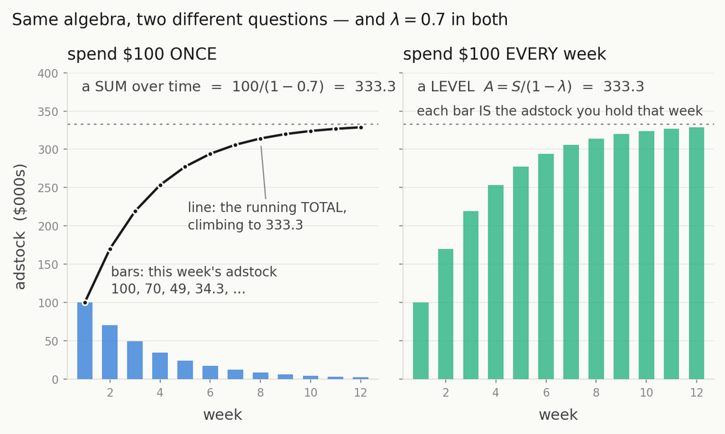

Left is a **total over time**. Right is a **level in one week**. Same 333.3 — different objects, and budget optimization uses the right-hand one.

## Hill Function: Saturation

More spend → more impact, up to a ceiling the curve never passes.

$$H(s) = \frac{s^\alpha}{\text{EC}_{50}^\alpha + s^\alpha}, \qquad s = A_t \;\text{(adstock, not raw spend)}$$

**Parameters:**

- $\text{EC}_{50}$ = **adstocked** spend level at 50% of max impact  
  ($H(\text{EC}_{50}) = 0.5$, always)
- $\alpha$ = the **exponent**, the shape parameter; never moves EC$_{50}$  
  ($\alpha \leq 1$: concave; $\alpha > 1$: **S-shaped**.  
  Examples use $\alpha = 2$; a fitted model **estimates** $\alpha$)

**Output $H(s) \in [0, 1]$** ($\text{EC}_{50} = 100$, $\alpha = 2$)**:**

| $s$ | $H(s)$ | $\Delta H$ | per unit |
| --- | --- | --- | --- |
| 0 | 0.000 | — | — |
| 50 | 0.200 | +0.200 | 0.0040 |
| 100 (EC₅₀) | **0.500** | **+0.300** | **0.0060** |
| 200 | 0.800 | +0.300 | 0.0030 |
| 300 | 0.900 | +0.100 | 0.0010 |

**Warning**

**The steps are not equal-sized — read the *per unit* column. That is the Hill slope $H'(s)$: what one more unit of *adstock* buys** (converting that to a spend dollar comes three slides on)**.** It *rises*, 0.0040 → 0.0060, so the second $50k buys **more** than the first. With $\alpha = 2$ the curve is S-shaped: returns increase up to the inflection at $\text{EC}_{50}/\sqrt{3} \approx 58$, and “saturating” ≠ “concave everywhere”.

## Why the Slope Panel Is the One That Proves It

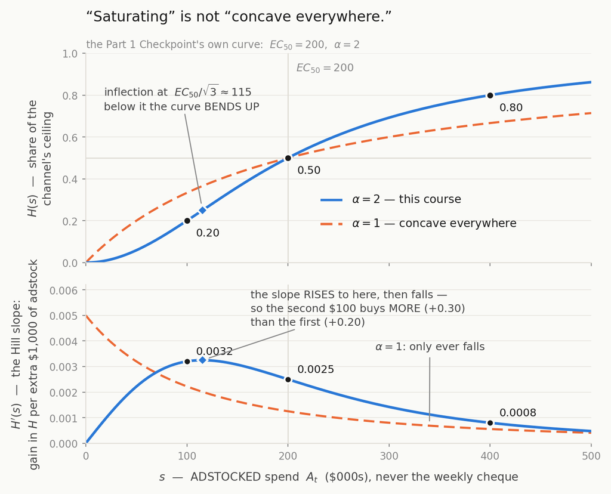

The **bottom** panel is $H'(s)$ — the *per unit* column. Marginal ROI is this, times $\beta_j$, times $1/(1-\lambda_j)$.

## EC₅₀ Lives on the Adstock Scale

**Warning**

The Hill function is applied to $H(A_t)$, never $H(S_t)$. So **EC₅₀ is an *adstocked* spend level**, and “spend” next to a Hill response always means adstocked spend in this course.

Since $A_t = S_t + \lambda A_{t-1}$ with $\lambda \geq 0$, **adstock $\geq$ raw spend** — at steady state $A = S/(1-\lambda)$, which is $4\times$ raw spend at $\lambda = 0.75$.

**Consequence for reading output**

$H > 0.5 \Leftrightarrow$ **adstock** above EC₅₀. It says nothing about this week’s spend $S_t$.

**The standard misreading**

Comparing a fitted EC₅₀ against the raw spend column. It always errs the same way: you think you have more **headroom** — room to add spend before the curve flattens — than you do.

## Marginal ROI: What the Next Dollar Buys

**Marginal ROI** = the revenue gained from the next $1 of **weekly spend** — a derivative with respect to $S_j$, taken by the chain rule (derived in full in the notes, §1.4C):

$$\text{MR}_j = \frac{d\,\text{Rev}}{dS_j} = \underbrace{\beta_j}_{d\text{Rev}/dH} \times \underbrace{H'(A_j)}_{dH/dA} \times \underbrace{\frac{dA_j}{dS_j}}_{dA/dS}$$

**Link 2 — the Hill slope,** the *per unit* column two slides back (from $H = 1 - k/(k+s^\alpha)$, $k = \text{EC}_{50}^\alpha$):

$$H'(s) = \frac{\alpha \cdot \text{EC}_{50}^\alpha \cdot s^{\alpha-1}}{(\text{EC}_{50}^\alpha + s^\alpha)^2}, \qquad s = A_{j,t}$$

**Important**

**Link 3 — you buy spend, not adstock.** At steady state $A = S/(1-\lambda)$, so one extra dollar of weekly spend, every week, buys $1/(1-\lambda)$ units of adstock — **5.6 for TV at $\lambda = 0.82$, 1.2 for paid search at $\lambda = 0.19$.** Hence

$$\text{MR}_j = \frac{\beta_j \cdot H'(A_j)}{1 - \lambda_j}$$

Rank on $\beta \cdot H'$ alone and you compare channels on a scale neither of them buys in — the long-memory channel is under-credited. Two channels differing *only* in $\lambda$ (0.8 vs 0.2; $\beta = 100$, EC₅₀ $= 100$, $\alpha = 2$, budget 100): the $\beta H'$ rule splits **20 / 80**, the full MR **40.7 / 59.3** — 2-to-1, and 13.8% of achievable revenue lost (worked in the notes).

## Marginal ROI: Three Factors, None Sufficient

$\beta_j$ is how much the channel *could* produce, $H'$ is how hard the next unit of adstock works **now**, $1/(1-\lambda_j)$ is how much adstock a dollar buys.

**Important**

**$H$ alone is not the budget rule.** “Digital $H = 0.30$, TV $H = 0.75$, so fund Digital” does not follow — $H$ places a channel on **its own** curve. The comparable number is $\beta_j H'(A_j)/(1-\lambda_j)$, and a large $\beta$ — or a long memory — can outweigh being further up the saturation curve.

## Budget Allocation

**Budget reallocation rule:**

Move a small step of budget from the **lowest**-MR channel to the **highest**, recompute, repeat — MR being the full $\beta_j H'(A_j)/(1-\lambda_j)$. At the best split every funded channel shares one MR; any dropped channel’s MR is no higher.

**Why revenue, not profit:** the total budget is fixed, so cost is the same under every split and the revenue-maximizing split is also the profit-maximizing one.¹

**Warning**

**Equal MR is necessary, not sufficient.** With S-shaped curves several splits can have equal MRs, some of them revenue *minima*, and the best split can be a **corner** that drops a channel. Compare predicted revenue — which is what a numerical optimizer does. And never shift the **entire** budget at once: past the inflection, MR falls as spend rises.

¹ If the budget can change, how much to spend in total is a different decision — not covered here.

## Reallocation Example

Channel A: MR = $4.00 per dollar spent  
Channel B: MR = $1.50 per dollar spent

**Revenue gain from shifting $1,000 from B to A:**

$$\Delta R \approx (4.00 - 1.50) \times 1{,}000 = \mathbf{\$2{,}500}$$

**Warning**

**Read that ≈ sign.** It holds both MRs *fixed* across the whole $1,000, and they are not. Past both inflections the true gain is **less** than $2,500; below them it can be **more**; and over a big enough shift the MRs cross and further dollars *lose* revenue. So it is a first-order estimate of a **small** step — small meaning neither MR changes much across it. Hence “one step, then re-compute”.

**Tip**

Equal marginal ROI ≠ equal budget — and equal MR marks a candidate optimum, to be checked on predicted revenue.

## Estimation Procedure

```python
# A standard way to fit an MMM (simplified): lambda, EC50, alpha are ESTIMATED, not chosen
def sse(params):                      # params = (lam, ec50, alpha) for each of 3 channels
    X = [hill(adstock(spend_c, lam_c), ec50_c, alpha_c) for each channel c]
    betas = least_squares(revenue, X)  # beta_0 + 3 betas: Lecture 2's OLS
    return sum((revenue - predict(betas, X))**2)

best = differential_evolution(sse, bounds, seed=42)   # search the 9 curve parameters jointly
```

Least squares, **not Bayesian** — one best fit, not a distribution. (Meridian and PyMC-Marketing are Bayesian; Robyn uses ridge regression plus the Nevergrad optimizer.)

**What the model returns:**

- $\beta_j$: channel contribution coefficient — the channel’s revenue **plateau**, since $H \leq 1$
- $\beta_0$: the **intercept** — baseline revenue with every channel’s $H$ at 0. Not a channel’s plateau; reading it as one overstates what advertising does
- $\lambda_j$, $\alpha_j$: fitted decay rate and shape per channel
- $\text{EC}_{50,j}$: half-saturation point per channel, **on the adstock scale**
- Marginal ROI curve at any budget level

## Scope and Limitations

**Estimands**

- Channel contribution to revenue, accounting for adstock carryover and saturation
- Marginal return to spend at current adstock level per channel
- Optimal reallocation direction given current marginal returns

**Identification**

MMM estimates are **observational**, not causal. Geo-holdout experiments — withholding a channel in a randomly assigned treatment region — provide causal validation. Cross-validate with Shapley attribution (Lecture 6).  
**Collinearity** across correlated channels is a common source of instability in $\hat{\beta}_j$.

## Checkpoint

1. $\lambda = 0.6$, spend sequence $S_1 = 200$, $S_2 = 0$, $S_3 = 50$. Compute $A_1$, $A_2$, $A_3$.
2. Channel EC₅₀ = 200, $\alpha = 2$. Compute $H(100)$, $H(200)$, $H(400)$.
3. A model fits TV’s decay at $\lambda = 0.82$ and paid search’s at $\lambda = 0.19$. What does that say about how the two should be **scheduled**?
4. Why can’t you shift the entire social budget to TV immediately?
5. Last-touch attribution shows Digital = 70% of conversions, TV = 10%. MMM shows TV = 35% contribution. Which is right — and why might they differ?

Answers in the lecture notes, under “Slide Checkpoint Answers” (numbered to match this slide).